# Project 2 Write Up

Mihir Gadil, Elie Tetteh-Wayoe, Jessica Fogerty, Aluya Omofuma, Pierre Bamba

11/17/2018

## Introduction

The Olympic games is international sporting events featuring winter and summer sporting competitions for men and women. The Olympics games is arguably the most prestigious sporting event in the world and its popularity is on the increase. In the 2016 edition held in Rio-Brazil, there were 306 events compared to the very first Olympic games in 1896 held in Athens-Greece which only had 43 events. The growth of the Olympics has been a trend from the early years of the event. In the 1950s, after the second world war and the cusp of the cold war the number of events had tripled to 150 from the very first Olympics. The growth continued till present time although it slowed down a bit. There might be an increase in the number of unique events over the next few years, but it would most likely be minute. The focus of our study is to build on our previous work and create a model that will beable to predict the proportion of medals won at future Olympic Games. Our SMART question is: What proportion of medals will Japan (the next Olympic host country) win during the 2020 Summer Olympic games. Previously we were able to answer the question: Does the host country have an advantage in the olympics? The answer was yes, that the host team preforms better than their performances when not a host team. Drawing on previous Olympic model building research we will be taking the following variable into consideration: GDP per Capita, Population, historical medal counts, planned economy (communist economy), soviet (or was once a soviet) nation, host country (is or isn’t). The previous research that we referenced used the variables that were listed ans used the log of GDP, GDP per Capita, and Population, so we followed suit.

## Exploratory Data Analysis

*Olympic Data Set*

We first started our EDA process by importing the Olympic data from: https://www.kaggle.com/heesoo37/120-years-of-olympic-history-athletes-and-results. The first thing we did was add a Host_Country Column. We then noticed that each athlete was awarded a medal including each team member, we were able to subset the data so that each team was awarded one medal so that there was no discrepency. We changed the structure of some of the columns such as medal, changed to ordered factor. We dropped Age, Height, Weight, City and Games. Next we insert host country data into the data frame. Change some country codes to simplify analysis and select only the Summer Olympics data. Next we created a seperate dataframe with only athletes that have won a medal. We also created an additional data frame with year and total medals won. We Examined the structure of the data frame and then examined the five statistic summary.

```
## 'data.frame':    220819 obs. of  11 variables:
##  $ Year    : int  1896 1896 1896 1896 1896 1896 1896 1896 1896 1896 ...
##  $ ID      : int  41160 74612 105467 35741 35741 85456 89416 28169 56757 56757 ...
##  $ Name    : Factor w/ 134732 levels "  Gabrielle Marie \"Gabby\" Adcock (White-)",..: 27431 66087 111990 44532 44532 67728 40999 41004 44919 44919 ...
##  $ Sex     : Factor w/ 2 levels "F","M": 2 2 2 2 2 2 2 2 2 2 ...
##  $ Team    : Factor w/ 1184 levels "30. Februar",..: 419 399 419 399 399 399 419 419 477 477 ...
##  $ NOC     : chr  "GRE" "GER" "GRE" "GER" ...
##  $ Season  : Factor w/ 2 levels "Summer","Winter": 1 1 1 1 1 1 1 1 1 1 ...
##  $ Sport   : Factor w/ 66 levels "Aeronautics",..: 6 28 48 28 28 28 48 48 28 28 ...
##  $ Event   : Factor w/ 765 levels "Aeronautics Mixed Aeronautics",..: 102 375 524 376 377 368 510 530 366 374 ...
##  $ Medal   : Ord.factor w/ 3 levels "Bronze"<"Silver"<..: 1 3 NA NA NA NA NA NA NA NA ...
##  $ Host_NOC: chr  "GRE" "GRE" "GRE" "GRE" ...
```

```
##       Year            ID                                       Name
##  Min.   :1896   Min.   :     1   Robert Tait McKenzie            :    58
##  1st Qu.:1960   1st Qu.: 33988   Heikki Ilmari Savolainen        :    39
##  Median :1984   Median : 68266   Joseph "Josy" Stoffel           :    38
##  Mean   :1977   Mean   : 67978   Ioannis Theofilakis             :    33
##  3rd Qu.:2000   3rd Qu.:101862   Takashi Ono                     :    33
##  Max.   :2016   Max.   :135568   Alfrd (Arnold-) Hajs (Guttmann-):    32
##                                  (Other)                         :220586
##  Sex                   Team            NOC               Season
##  F: 59432   United States: 14445   Length:220819      Summer:220819
##  M:161387   Great Britain: 10205   Class :character   Winter:     0
##             France       :  9872   Mode  :character
##             Italy        :  8004
##             Germany      :  7221
##             Australia    :  6966
##             (Other)      :164106
##         Sport                                           Event
##  Athletics : 38154   Football Men's Football               :  5688
##  Gymnastics: 26551   Hockey Men's Hockey                   :  3958
##  Swimming  : 23117   Water Polo Men's Water Polo           :  3358
##  Shooting  : 11128   Basketball Men's Basketball           :  3280
##  Cycling   : 10721   Cycling Men's Road Race, Individual   :  2923
##  Fencing   : 10574   Gymnastics Men's Individual All-Around:  2475
##  (Other)   :100574   (Other)                               :199137
##     Medal          Host_NOC
##  Bronze: 11264   Length:220819
##  Silver: 11064   Class :character
##  Gold  : 11302   Mode  :character
##  NA's  :187189
##
##
##
```

*Country Statistics Dataset*

We then imported the GDP, Population, and per capita GDP data from: https://www.rug.nl/ggdc/historicaldevelopment/maddison/releases/maddison-project-database-2018. We used the Real GDP per Capita in 2011 USD and the Population in thousands. The first step we took to prepare this data for analysis was to change the column names to match the athlete columns. We also selected to keep data later than the year 1896. We alsp multiplied Population by 1000 because it was in 1000’s and we wanted the actual Population of each country. The next step we took was to find the whole world’s GDP by year, by using that we were able to calculate the share of GDP per country per year. We also examined the structure and summary of this dataset.

```
## Classes 'tbl_df', 'tbl' and 'data.frame':    14617 obs. of  7 variables:
##  $ NOC       : chr  "AFG" "AFG" "AFG" "AFG" ...
##  $ Country   : chr  "Afghanistan" "Afghanistan" "Afghanistan" "Afghanistan" ...
##  $ Year      : num  1913 1950 1951 1952 1953 ...
##  $ GDPPC     : num  NA 2392 2422 2462 2568 ...
##  $ Population: num  5730000 8150000 8284000 8425000 8573000 ...
##  $ GDP       : num  NA 1.95e+10 2.01e+10 2.07e+10 2.20e+10 ...
##  $ GDPShare  : num  NA 0.00236 0.00229 0.00225 0.00226 ...
```

```
##      NOC              Country               Year          GDPPC
##  Length:14617       Length:14617       Min.   :1896   Min.   :   134
##  Class :character   Class :character   1st Qu.:1952   1st Qu.:  1755
##  Mode  :character   Mode  :character   Median :1973   Median :  4018
##                                        Mean   :1970   Mean   :  8366
##                                        3rd Qu.:1995   3rd Qu.:  9914
##                                        Max.   :2016   Max.   :220717
##                                                       NA's   :1346
##    Population             GDP               GDPShare
##  Min.   :1.100e+04   Min.   :6.378e+07   Min.   :0.0000
##  1st Qu.:2.293e+06   1st Qu.:7.630e+09   1st Qu.:0.0003
##  Median :6.110e+06   Median :2.697e+10   Median :0.0013
##  Mean   :2.929e+07   Mean   :2.408e+11   Mean   :0.0092
##  3rd Qu.:1.790e+07   3rd Qu.:1.210e+11   3rd Qu.:0.0048
##  Max.   :1.373e+09   Max.   :1.721e+13   Max.   :0.4357
##  NA's   :114         NA's   :1458        NA's   :1458
```

*Model Building Preparation*

To prepare for the model building process we first created a dataframe called medal_counts, this consisted of the medal counts, the country code. We specified that it would be countries that have earned five or more medals in the year 2012. We also added a column that stated whether the country is the host country or not. The time range we selected is from 1988 to 2016. Next we created a column that stated is the country has a planned (communist) economy, and another that states if a country is or has been a part of the Soviet Union. We dropped the following two country codes: “EUN”, “SCG”. Our final data frame that we used is a merge of the medal counts data frame and the GDP and Population data. Finally we created a column with the proportion of medals. We added another column that states the medal proportions for each country from previous Olympic games.

## Model Building

*Model Development*

To develop our model we began by dividing the data into training and test sets. The training data was from 1988 to 2012 and the test data was the year 2016. The variables we wanted to take into consideration where: is_host, planned_economy, is_soviet, log(GDPPC), log(Population), log(GDP), GDPShare, pre_proportion, Total_Medals. We began by looking at box plots of is_host and planned_economy to makes sure the distributions were different.

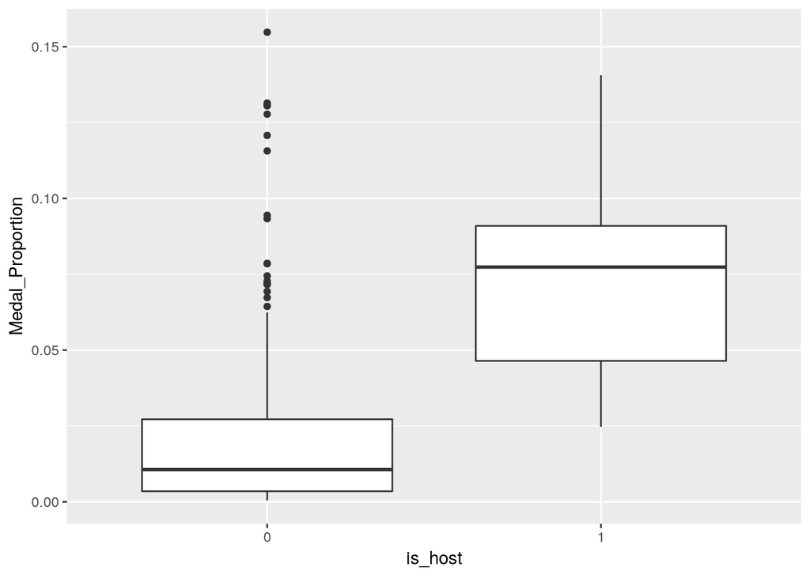

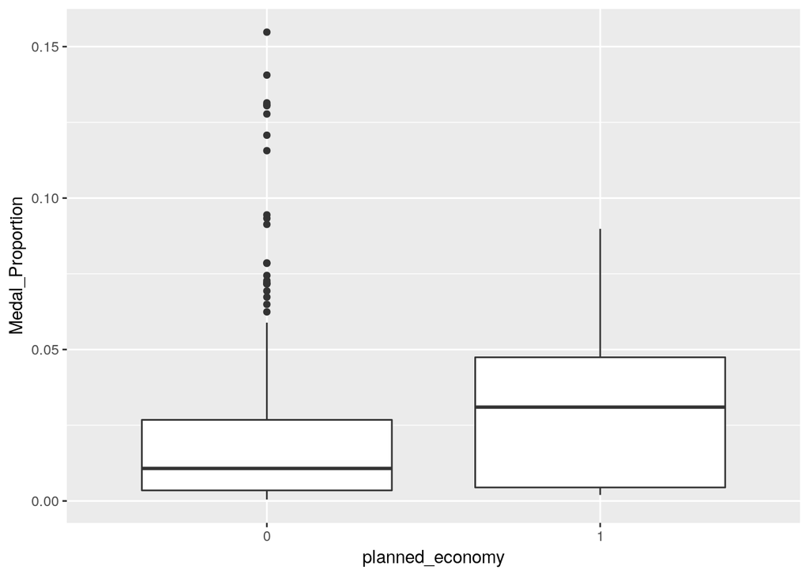

After examining the box plots, we can see that means appear visually different between both is_host and planned_economy variables. Next we created a correlation plot between the numerical variables. By doing so we can see that the variables that correlate with Medal_Proportion are: log(GDP), log(GDPPC), log(Population), GDPShare, prev_proportion.

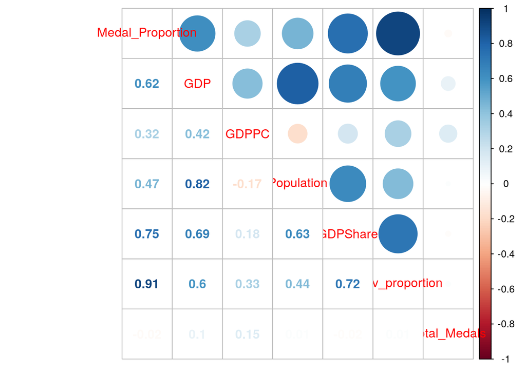

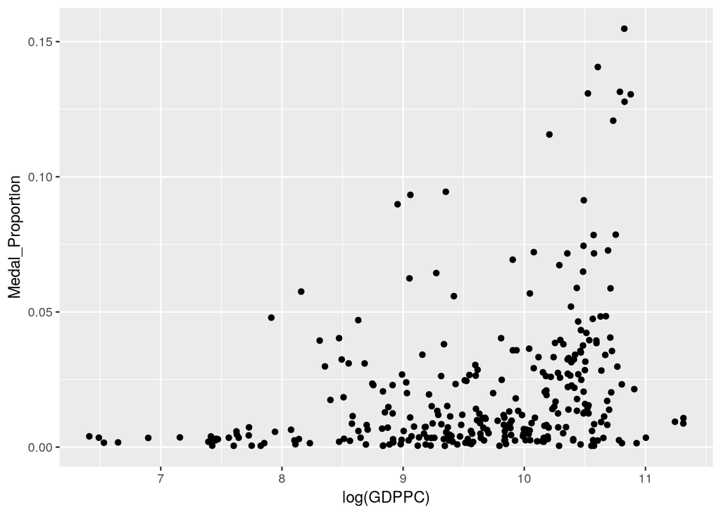

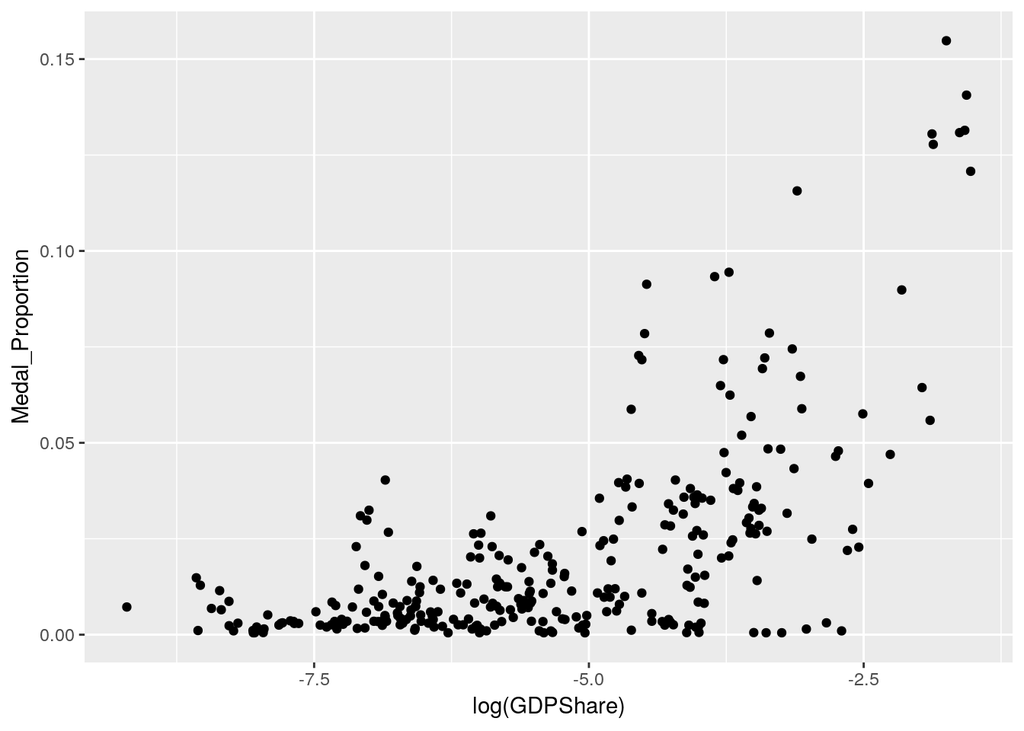

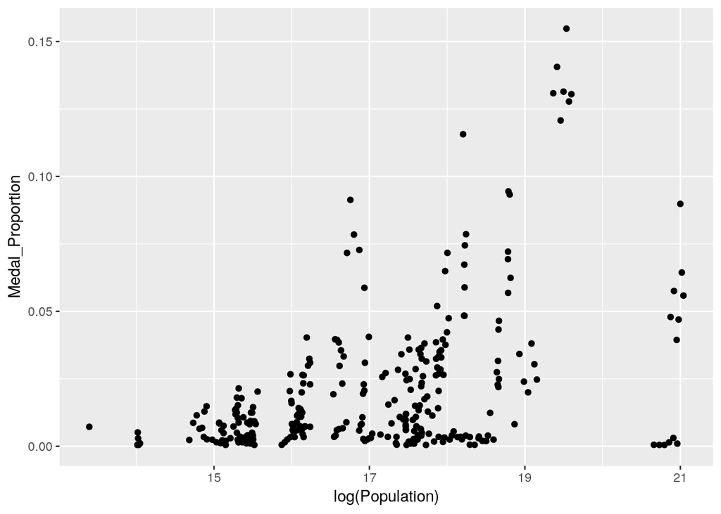

## The Model

*The Model We Created*

The variables that we found created the best model (as stated earlier) are prev_proportion, GDPShare, and is_host. We incorporated these variables into the linear model and trained the model, using the training dataset. The model can be seen below. The VIF values for these variables are all around 2 and 1, indicating that there is not much multicollinearity between these variables. The small p-values that these variables have indicate that they are statistically significant in our model. Our adjusted R squared is 86.61 percent, this accounts for much of the variance in the data.

```r
#Prediction model
medal_model <- lm(Medal_Proportion ~ prev_proportion + GDPShare + is_host, data = training_data)
summary(medal_model)
```

```
##
## Call:
## lm(formula = Medal_Proportion ~ prev_proportion + GDPShare +
##     is_host, data = training_data)
##
## Residuals:
##       Min        1Q    Median        3Q       Max
## -0.025255 -0.004826 -0.002236  0.003704  0.054830
##
## Coefficients:
##                  Estimate Std. Error t value Pr(>|t|)
## (Intercept)     0.0038527  0.0007591   5.076 7.53e-07 ***
## prev_proportion 0.6955991  0.0311435  22.335  < 2e-16 ***
## GDPShare        0.1541476  0.0268227   5.747 2.63e-08 ***
## is_host1        0.0293705  0.0046179   6.360 9.47e-10 ***
## ---
## Signif. codes:  0 '***' 0.001 '**' 0.01 '*' 0.05 '.' 0.1 ' ' 1
##
## Residual standard error: 0.009922 on 251 degrees of freedom
## Multiple R-squared:  0.8677, Adjusted R-squared:  0.8661
## F-statistic: 548.5 on 3 and 251 DF,  p-value: < 2.2e-16
```

```r
vif(medal_model)
```

```
## prev_proportion        GDPShare        is_host1
##        2.079466        2.129171        1.061938
```

*Reliability of results*

As seen above in the model summary, we can see that the adjusted R squared is 86.61%, indicating a good model. We can see below that we made a prediction for Japan in the 2020 Olympic Games, which is in Tokyo. The values that we used were GDPShare and the prev_proportion. The GDPShare was a predicted value that we obtained from tradingeconomics.com. Our model predicted that Japan will win 6.3% of the Proportion of Medals.

```
## 0.06374145
```

Next we wanted to see the reliability of our results, we tested out model on the USA in the year 2016. Our model predicted that the US would have 11.6% of the Proportion of Medals. The actual was 13.0%

```
## 0.1162911
```

Below we can see the mean error in the prediction, which is .12 and the standard deviation is 1.08. This indicated that the model error could have essentially been 0 because it falls in the 95% confidence interval.

```
## [1] 0.1236875
```

```
## [1] 1.078295
```

*Predictions we can make*

By using this model we can predict the proportion of medals that each country will win at future Summer Olympic games with a model that explains the variance by 86.61%. In order to improve the model accuracy we could include the athletes of each country by discipline, this could improve accuracy because we would know how many medals each athlete has won.

## Citations

1. “120 years of Olympic history: athletes and results.” [Online]. Available: https://www.kaggle.com/heesoo37/120-years-of-olympic-history-athletes-and-results.
2. Maddison Project Database, version 2018. Bolt, Jutta, Robert Inklaar, Herman de Jong and Jan Luiten van Zanden (2018), “Rebasing ‘Maddison’: new income comparisons and the shape of long-run economic development”, Maddison Project Working paper 10  
   For the references to the original research on individual countries, see Appendix A of Bolt et al. (2018).
3. “TRADING ECONOMICS | 20 million INDICATORS FROM 196 COUNTRIES.” [Online]. Available: https://tradingeconomics.com/.
4. A. B. Bernard and M. R. Busse, “Who Wins the Olympic Games: Economic Resources and Medal Totals,” Review of Economics and Statistics, vol. 86, no. 1, pp. 413–417, Feb. 2004.
5. C. F. Gonzales, “Going for the Gold in the Cidade Maravilhosa: Who Will Win the 2016 Olympic Games in Rio de Janeiro?,” p. 9.